# Definición y Uso de Funciones en R

Marlon

2025-07-24

# Introducción

En R, las funciones son bloques de código reutilizables que permiten realizar tareas específicas. Saber definir y utilizar funciones es fundamental para automatizar análisis, mejorar la organización del código y evitar repeticiones.

En este documento aprenderás cómo utilizar funciones base, cómo definir tus propias funciones, cómo usarlas con vectores y cómo graficar sus resultados.

## Funciones base en R

R incluye muchas funciones ya incorporadas (“funciones base”) que facilitan operaciones comunes con números, vectores y otros objetos. Algunas de las más usadas son:

## Potencia

```r
2^3          # Resultado: 8
```

```
## [1] 8
```

```r
2**3 # Resultado: 8
```

```
## [1] 8
```

## Raíz cuadrada

Se usa la función `sqrt()`:

```r
sqrt(9)      # Resultado: 3
```

```
## [1] 3
```

```r
sqrt(c(4, 9, 16)) # Resultado: 2 3 4
```

```
## [1] 2 3 4
```

```r
9**(1/2)
```

```
## [1] 3
```

## Suma de elementos

La función `sum()` calcula la suma total de un vector:

```r
sum(c(1, 2, 3, 4)) # Resultado: 10
```

```
## [1] 10
```

## Producto de elementos

La función `prod()` calcula el producto de todos los elementos de un vector:

```r
prod(c(1, 2, 3, 4)) # Resultado: 24
```

```
## [1] 24
```

## Suma acumulada

La función `cumsum()` entrega la suma acumulada de un vector:

```r
cumsum(c(1, 2, 3, 4)) # Resultado: 1 3 6 10
```

```
## [1]  1  3  6 10
```

## Promedio (media aritmética)

La función `mean()` retorna el promedio de los valores de un vector:

```r
mean(c(5, 7, 9)) # Resultado: 7
```

```
## [1] 7
```

## Desviación estándar

La función `sd()` calcula la desviación estándar de un vector numérico:

```r
sd(c(5, 7, 9)) # Resultado: 2
```

```
## [1] 2
```

## Valor máximo y mínimo

Las funciones `max()` y `min()` retornan el mayor y menor valor de un vector:

```r
max(c(2, 8, 3, 5)) # Resultado: 8
```

```
## [1] 8
```

```r
min(c(2, 8, 3, 5)) # Resultado: 2
```

```
## [1] 2
```

## Longitud de un vector

La función `length()` indica cuántos elementos tiene un vector:

```r
length(c(10, 20, 30, 40)) # Resultado: 4
```

```
## [1] 4
```

## Redondeo

- `round(x)` redondea al entero más cercano.
- `floor(x)` redondea hacia abajo.
- `ceiling(x)` redondea hacia arriba.

```r
round(3.6)   # Resultado: 4
```

```
## [1] 4
```

```r
floor(3.6)   # Resultado: 3
```

```
## [1] 3
```

```r
ceiling(3.2) # Resultado: 4
```

```
## [1] 4
```

Estas funciones base te permiten operar y analizar datos rápidamente sin necesidad de definir funciones propias.

## Ejercicios

1. ¿Cómo puedes calcular el valor de 5 elevado a la 4 en R? Escribe dos formas distintas de hacerlo.
2. ¿Qué resultado obtienes al calcular la raíz cuadrada de los números 16, 25 y 36 en R? Escribe el código y el resultado esperado.
3. Crea un vector con los valores 3, 5, 7 y 9. ¿Cómo calcularías la suma total y el producto de sus elementos usando funciones base?
4. Dado el vector v <- c(1, 3, 6, 10), ¿cómo obtienes la suma acumulada de sus elementos? ¿Qué resultado esperas?
5. ¿Cómo obtendrías el promedio de los números del 1 al 100 en R? Escribe el código.
6. ¿Cuál es la desviación estándar de los números 10, 12, 13, 17 y 20? Usa la función correspondiente.
7. Para el vector c(11, 27, 5, 19), ¿cómo encontrarías el valor máximo y el valor mínimo?
8. ¿Cómo puedes saber cuántos elementos tiene el vector c(2, 4, 6, 8, 10, 12)?
9. Redondea el número 7.65 al entero más cercano, al menor entero y al mayor entero. ¿Qué funciones usas y qué resultados obtienes?
10. ¿Qué sucede si aplicas la función sum() a un vector vacío, como sum(c())? ¿Y la función prod()?

## Definir funciones en R

Una función en R es un conjunto de instrucciones agrupadas bajo un nombre, que puede recibir valores de entrada (argumentos), procesarlos y devolver un resultado (output).

La estructura general de una función en R es la siguiente:

```r
nombre_funcion <- function(argumentos) {
  # Cuerpo de la función
  resultado <- ... # Operaciones
  return(resultado)
}
```

## Ejemplo simple

```r
# Una función que suma dos números
sumar <- function(a, b) {
  resultado <- a + b
  return(resultado)
}

sumar(3, 5) # Resultado: 8
```

```
## [1] 8
```

# Funciones que trabajan con vectores

En R, es común trabajar con vectores numéricos. Las funciones pueden procesar estos vectores y devolver resultados útiles.

## Ejemplo 1: Suma de todos los elementos de un vector

```r
suma_vector <- function(vec) {
  suma <- sum(vec)
  return(suma)
}

mi_vector <- c(2, 4, 6, 8)
suma_vector(mi_vector) # Resultado: 20
```

```
## [1] 20
```

## Ejemplo 2: Calcular el promedio de un vector

```r
promedio_vector <- function(vec) {
  promedio <- mean(vec)
  return(promedio)
}

promedio_vector(c(10, 20, 30)) # Resultado: 20
```

```
## [1] 20
```

## Ejemplo 3: Función que calcula la desviación estándar de un vector

```r
desviacion_vector <- function(vec) {
  desv <- sd(vec)
  return(desv)
}

desviacion_vector(c(5, 7, 11, 15))
```

```
## [1] 4.434712
```

# Ejemplo: Función definida por el usuario y graficar su resultado

Supongamos que queremos crear una función $f(x) = x^2 - 2x + 1$ y graficarla en el intervalo [-5, 5].

## Definir la función

```r
f <- function(x) {
  return(x^2 - 2*x + 1)
}
```

## Crear un vector de valores para x

```r
x <- seq(-5, 5, by = 0.1) # Vector desde -5 hasta 5, de 0.1 en 0.1
y <- f(x)
```

## Graficar la función

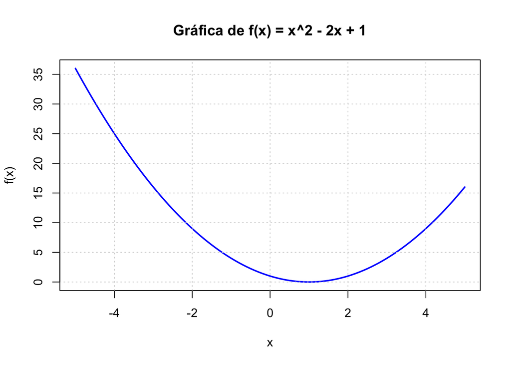

```r
plot(x, y, type = "l", col = "blue", lwd = 2,
     main = "Gráfica de f(x) = x^2 - 2x + 1",
     xlab = "x", ylab = "f(x)")
grid()
```

# Ejercicios prácticos

1. **Crear una función que reciba un vector numérico y devuelva el valor máximo y mínimo como una lista.**
2. **Definir una función que, dado un vector, devuelva un nuevo vector con cada elemento elevado al cuadrado. Pruébala con el vector c(1, 2, 3, 4, 5).**
3. **Crear una función que calcule la suma acumulada de un vector (usa la función cumsum de R). Grafica la suma acumulada usando plot().**
4. **Define una función g(x) = sin(x) y grafícala en el intervalo [0, 2π].**